# Risk Factor Analysis

## Outcome Variable

**Outcome Variable:** sstunted

## Predictor Variables

**Intervention Variable:** month

**Adjustment Set:**

unadjusted

## Stratifying Variables

The analysis was stratified on these variable(s):

- agecat
- studyid
- country

## Data Summary

| agecat | studyid | country | month | sstunted | n_cell | n |
| --- | --- | --- | --- | --- | --- | --- |
| Birth | CMC-V-BCS-2002 | INDIA | 1 | 0 | 9 | 92 |
| Birth | CMC-V-BCS-2002 | INDIA | 1 | 1 | 0 | 92 |
| Birth | CMC-V-BCS-2002 | INDIA | 2 | 0 | 1 | 92 |
| Birth | CMC-V-BCS-2002 | INDIA | 2 | 1 | 0 | 92 |
| Birth | CMC-V-BCS-2002 | INDIA | 3 | 0 | 7 | 92 |
| Birth | CMC-V-BCS-2002 | INDIA | 3 | 1 | 1 | 92 |
| Birth | CMC-V-BCS-2002 | INDIA | 4 | 0 | 9 | 92 |
| Birth | CMC-V-BCS-2002 | INDIA | 4 | 1 | 0 | 92 |
| Birth | CMC-V-BCS-2002 | INDIA | 5 | 0 | 11 | 92 |
| Birth | CMC-V-BCS-2002 | INDIA | 5 | 1 | 0 | 92 |
| Birth | CMC-V-BCS-2002 | INDIA | 6 | 0 | 10 | 92 |
| Birth | CMC-V-BCS-2002 | INDIA | 6 | 1 | 0 | 92 |
| Birth | CMC-V-BCS-2002 | INDIA | 7 | 0 | 7 | 92 |
| Birth | CMC-V-BCS-2002 | INDIA | 7 | 1 | 0 | 92 |
| Birth | CMC-V-BCS-2002 | INDIA | 8 | 0 | 4 | 92 |
| Birth | CMC-V-BCS-2002 | INDIA | 8 | 1 | 0 | 92 |
| Birth | CMC-V-BCS-2002 | INDIA | 9 | 0 | 7 | 92 |
| Birth | CMC-V-BCS-2002 | INDIA | 9 | 1 | 1 | 92 |
| Birth | CMC-V-BCS-2002 | INDIA | 10 | 0 | 9 | 92 |
| Birth | CMC-V-BCS-2002 | INDIA | 10 | 1 | 1 | 92 |
| Birth | CMC-V-BCS-2002 | INDIA | 11 | 0 | 11 | 92 |
| Birth | CMC-V-BCS-2002 | INDIA | 11 | 1 | 0 | 92 |
| Birth | CMC-V-BCS-2002 | INDIA | 12 | 0 | 3 | 92 |
| Birth | CMC-V-BCS-2002 | INDIA | 12 | 1 | 1 | 92 |
| Birth | CMIN | BANGLADESH | 1 | 0 | 0 | 26 |
| Birth | CMIN | BANGLADESH | 1 | 1 | 1 | 26 |
| Birth | CMIN | BANGLADESH | 2 | 0 | 5 | 26 |
| Birth | CMIN | BANGLADESH | 2 | 1 | 1 | 26 |
| Birth | CMIN | BANGLADESH | 3 | 0 | 2 | 26 |
| Birth | CMIN | BANGLADESH | 3 | 1 | 0 | 26 |

[output cut: 1434 more lines]

The following strata were considered:

- agecat: 24 months, studyid: CMC-V-BCS-2002, country: INDIA
- agecat: 24 months, studyid: CMIN, country: BANGLADESH
- agecat: 24 months, studyid: CONTENT, country: PERU
- agecat: 24 months, studyid: EE, country: PAKISTAN
- agecat: 24 months, studyid: GMS-Nepal, country: NEPAL
- agecat: 24 months, studyid: IRC, country: INDIA
- agecat: 24 months, studyid: Keneba, country: GAMBIA
- agecat: 24 months, studyid: LCNI-5, country: MALAWI
- agecat: 24 months, studyid: MAL-ED, country: BANGLADESH
- agecat: 24 months, studyid: MAL-ED, country: BRAZIL
- agecat: 24 months, studyid: MAL-ED, country: INDIA
- agecat: 24 months, studyid: MAL-ED, country: NEPAL
- agecat: 24 months, studyid: MAL-ED, country: PERU
- agecat: 24 months, studyid: MAL-ED, country: SOUTH AFRICA
- agecat: 24 months, studyid: MAL-ED, country: TANZANIA, UNITED REPUBLIC OF
- agecat: 24 months, studyid: NIH-Birth, country: BANGLADESH
- agecat: 24 months, studyid: PROBIT, country: BELARUS
- agecat: 24 months, studyid: TanzaniaChild2, country: TANZANIA, UNITED REPUBLIC OF
- agecat: 24 months, studyid: ZVITAMBO, country: ZIMBABWE
- agecat: 6 months, studyid: CMC-V-BCS-2002, country: INDIA
- agecat: 6 months, studyid: CMIN, country: BANGLADESH
- agecat: 6 months, studyid: CONTENT, country: PERU
- agecat: 6 months, studyid: EE, country: PAKISTAN
- agecat: 6 months, studyid: GMS-Nepal, country: NEPAL
- agecat: 6 months, studyid: Guatemala BSC, country: GUATEMALA
- agecat: 6 months, studyid: IRC, country: INDIA
- agecat: 6 months, studyid: Keneba, country: GAMBIA
- agecat: 6 months, studyid: LCNI-5, country: MALAWI
- agecat: 6 months, studyid: MAL-ED, country: BANGLADESH
- agecat: 6 months, studyid: MAL-ED, country: BRAZIL
- agecat: 6 months, studyid: MAL-ED, country: INDIA
- agecat: 6 months, studyid: MAL-ED, country: NEPAL
- agecat: 6 months, studyid: MAL-ED, country: PERU
- agecat: 6 months, studyid: MAL-ED, country: SOUTH AFRICA
- agecat: 6 months, studyid: MAL-ED, country: TANZANIA, UNITED REPUBLIC OF
- agecat: 6 months, studyid: NIH-Birth, country: BANGLADESH
- agecat: 6 months, studyid: PROBIT, country: BELARUS
- agecat: 6 months, studyid: ResPak, country: PAKISTAN
- agecat: 6 months, studyid: SAS-CompFeed, country: INDIA
- agecat: 6 months, studyid: SAS-FoodSuppl, country: INDIA
- agecat: 6 months, studyid: TanzaniaChild2, country: TANZANIA, UNITED REPUBLIC OF
- agecat: 6 months, studyid: ZVITAMBO, country: ZIMBABWE
- agecat: Birth, studyid: CMC-V-BCS-2002, country: INDIA
- agecat: Birth, studyid: CMIN, country: BANGLADESH
- agecat: Birth, studyid: CONTENT, country: PERU
- agecat: Birth, studyid: EE, country: PAKISTAN
- agecat: Birth, studyid: GMS-Nepal, country: NEPAL
- agecat: Birth, studyid: IRC, country: INDIA
- agecat: Birth, studyid: Keneba, country: GAMBIA
- agecat: Birth, studyid: MAL-ED, country: BANGLADESH
- agecat: Birth, studyid: MAL-ED, country: BRAZIL
- agecat: Birth, studyid: MAL-ED, country: INDIA
- agecat: Birth, studyid: MAL-ED, country: NEPAL
- agecat: Birth, studyid: MAL-ED, country: PERU
- agecat: Birth, studyid: MAL-ED, country: SOUTH AFRICA
- agecat: Birth, studyid: MAL-ED, country: TANZANIA, UNITED REPUBLIC OF
- agecat: Birth, studyid: NIH-Birth, country: BANGLADESH
- agecat: Birth, studyid: PROBIT, country: BELARUS
- agecat: Birth, studyid: ResPak, country: PAKISTAN
- agecat: Birth, studyid: SAS-CompFeed, country: INDIA
- agecat: Birth, studyid: ZVITAMBO, country: ZIMBABWE

### Dropped Strata

Some strata were dropped due to rare outcomes:

- agecat: Birth, studyid: CMC-V-BCS-2002, country: INDIA
- agecat: Birth, studyid: CMIN, country: BANGLADESH
- agecat: Birth, studyid: CONTENT, country: PERU
- agecat: Birth, studyid: EE, country: PAKISTAN
- agecat: Birth, studyid: GMS-Nepal, country: NEPAL
- agecat: Birth, studyid: IRC, country: INDIA
- agecat: Birth, studyid: Keneba, country: GAMBIA
- agecat: Birth, studyid: MAL-ED, country: BANGLADESH
- agecat: Birth, studyid: MAL-ED, country: BRAZIL
- agecat: Birth, studyid: MAL-ED, country: INDIA
- agecat: Birth, studyid: MAL-ED, country: NEPAL
- agecat: Birth, studyid: MAL-ED, country: PERU
- agecat: Birth, studyid: MAL-ED, country: SOUTH AFRICA
- agecat: Birth, studyid: MAL-ED, country: TANZANIA, UNITED REPUBLIC OF
- agecat: Birth, studyid: NIH-Birth, country: BANGLADESH
- agecat: Birth, studyid: PROBIT, country: BELARUS
- agecat: Birth, studyid: ResPak, country: PAKISTAN
- agecat: Birth, studyid: SAS-CompFeed, country: INDIA
- agecat: 6 months, studyid: CMC-V-BCS-2002, country: INDIA
- agecat: 6 months, studyid: CMIN, country: BANGLADESH
- agecat: 6 months, studyid: CONTENT, country: PERU
- agecat: 6 months, studyid: EE, country: PAKISTAN
- agecat: 6 months, studyid: GMS-Nepal, country: NEPAL
- agecat: 6 months, studyid: Guatemala BSC, country: GUATEMALA
- agecat: 6 months, studyid: IRC, country: INDIA
- agecat: 6 months, studyid: Keneba, country: GAMBIA
- agecat: 6 months, studyid: LCNI-5, country: MALAWI
- agecat: 6 months, studyid: MAL-ED, country: BANGLADESH
- agecat: 6 months, studyid: MAL-ED, country: BRAZIL
- agecat: 6 months, studyid: MAL-ED, country: INDIA
- agecat: 6 months, studyid: MAL-ED, country: NEPAL
- agecat: 6 months, studyid: MAL-ED, country: PERU
- agecat: 6 months, studyid: MAL-ED, country: SOUTH AFRICA
- agecat: 6 months, studyid: MAL-ED, country: TANZANIA, UNITED REPUBLIC OF
- agecat: 6 months, studyid: NIH-Birth, country: BANGLADESH
- agecat: 6 months, studyid: ResPak, country: PAKISTAN
- agecat: 6 months, studyid: SAS-CompFeed, country: INDIA
- agecat: 6 months, studyid: SAS-FoodSuppl, country: INDIA
- agecat: 6 months, studyid: TanzaniaChild2, country: TANZANIA, UNITED REPUBLIC OF
- agecat: 24 months, studyid: CMC-V-BCS-2002, country: INDIA
- agecat: 24 months, studyid: CMIN, country: BANGLADESH
- agecat: 24 months, studyid: CONTENT, country: PERU
- agecat: 24 months, studyid: EE, country: PAKISTAN
- agecat: 24 months, studyid: GMS-Nepal, country: NEPAL
- agecat: 24 months, studyid: IRC, country: INDIA
- agecat: 24 months, studyid: LCNI-5, country: MALAWI
- agecat: 24 months, studyid: MAL-ED, country: BANGLADESH
- agecat: 24 months, studyid: MAL-ED, country: BRAZIL
- agecat: 24 months, studyid: MAL-ED, country: INDIA
- agecat: 24 months, studyid: MAL-ED, country: NEPAL
- agecat: 24 months, studyid: MAL-ED, country: PERU
- agecat: 24 months, studyid: MAL-ED, country: SOUTH AFRICA
- agecat: 24 months, studyid: MAL-ED, country: TANZANIA, UNITED REPUBLIC OF
- agecat: 24 months, studyid: NIH-Birth, country: BANGLADESH
- agecat: 24 months, studyid: PROBIT, country: BELARUS
- agecat: 24 months, studyid: TanzaniaChild2, country: TANZANIA, UNITED REPUBLIC OF
- agecat: 24 months, studyid: ZVITAMBO, country: ZIMBABWE

## Methods Detail

We’re interested in the causal parameters $E[Y_a]$ for all values of $a \in \mathcal{A}$. These parameters represent the mean outcome if, possibly contrary to fact, we intervened to set all units to have $A=a$. Under the randomization and positivity assumptions, these are identified by the statistical parameters $\psi_a=E_W[E_{Y|A,W}(Y|A=a,W)]$. In addition, we’re interested in the mean of $Y$, $E[Y]$ under no intervention (the observed mean). We will estimate these parameters by using SuperLearner to fit the relevant likelihood factors – $E_{Y|A,W}(Y|A=a,W)$ and $p(A=a|W)$, and then updating our likelihood fit using a joint TMLE.

For unadjusted analyses ($W=\{\}$), initial likelihoods were estimated using Lrnr_glm to estimate the simple $E(Y|A)$ and Lrnr_mean to estimate $p(A)$. For adjusted analyses, a small library containing Lrnr_glmnet, Lrnr_xgboost, and Lrnr_mean was used.

Having estimated these parameters, we will then use the delta method to estimate relative risks and attributable risks relative to a prespecified baseline level of $A$.

# Results Detail

## Results Plots

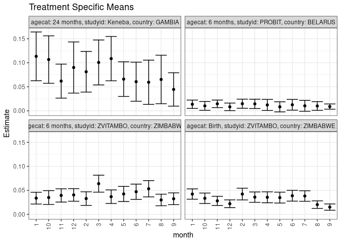

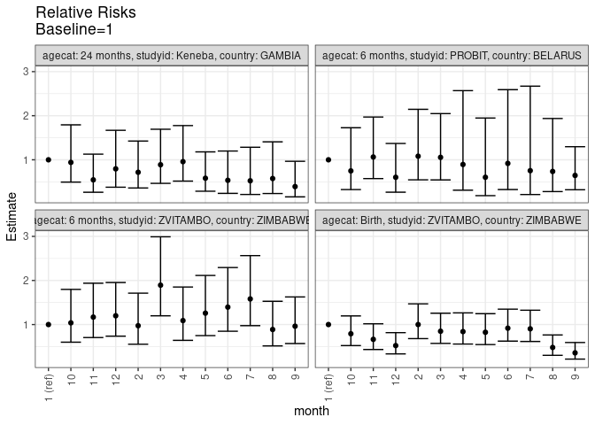

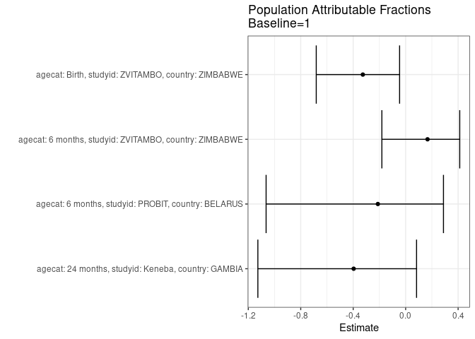

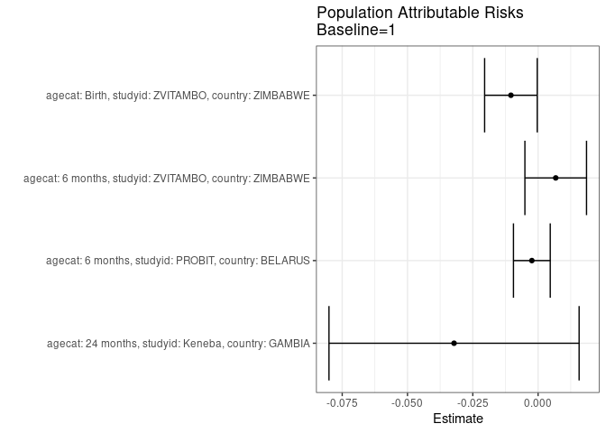

## Results Table

### Parameter: TSM

| agecat | studyid | country | intervention_level | baseline_level | estimate | ci_lower | ci_upper |
| --- | --- | --- | --- | --- | --- | --- | --- |
| Birth | ZVITAMBO | ZIMBABWE | 1 | NA | 0.0422535 | 0.0315182 | 0.0529888 |
| Birth | ZVITAMBO | ZIMBABWE | 2 | NA | 0.0422671 | 0.0300445 | 0.0544896 |
| Birth | ZVITAMBO | ZIMBABWE | 3 | NA | 0.0358392 | 0.0250670 | 0.0466114 |
| Birth | ZVITAMBO | ZIMBABWE | 4 | NA | 0.0355030 | 0.0241129 | 0.0468931 |
| Birth | ZVITAMBO | ZIMBABWE | 5 | NA | 0.0348606 | 0.0235141 | 0.0462070 |
| Birth | ZVITAMBO | ZIMBABWE | 6 | NA | 0.0387665 | 0.0275358 | 0.0499973 |
| Birth | ZVITAMBO | ZIMBABWE | 7 | NA | 0.0381679 | 0.0272307 | 0.0491051 |
| Birth | ZVITAMBO | ZIMBABWE | 8 | NA | 0.0202922 | 0.0124186 | 0.0281658 |
| Birth | ZVITAMBO | ZIMBABWE | 9 | NA | 0.0151286 | 0.0085484 | 0.0217088 |
| Birth | ZVITAMBO | ZIMBABWE | 10 | NA | 0.0334288 | 0.0225403 | 0.0443173 |
| Birth | ZVITAMBO | ZIMBABWE | 11 | NA | 0.0280702 | 0.0184817 | 0.0376587 |
| Birth | ZVITAMBO | ZIMBABWE | 12 | NA | 0.0220820 | 0.0139934 | 0.0301706 |
| 6 months | PROBIT | BELARUS | 1 | NA | 0.0136116 | 0.0048996 | 0.0223236 |
| 6 months | PROBIT | BELARUS | 2 | NA | 0.0147213 | 0.0052151 | 0.0242276 |
| 6 months | PROBIT | BELARUS | 3 | NA | 0.0143627 | 0.0046679 | 0.0240574 |
| 6 months | PROBIT | BELARUS | 4 | NA | 0.0121609 | 0.0006440 | 0.0236778 |
| 6 months | PROBIT | BELARUS | 5 | NA | 0.0082117 | -0.0022912 | 0.0187145 |
| 6 months | PROBIT | BELARUS | 6 | NA | 0.0125000 | 0.0013346 | 0.0236654 |
| 6 months | PROBIT | BELARUS | 7 | NA | 0.0102564 | -0.0010911 | 0.0216039 |
| 6 months | PROBIT | BELARUS | 8 | NA | 0.0100134 | 0.0008811 | 0.0191456 |
| 6 months | PROBIT | BELARUS | 9 | NA | 0.0087779 | 0.0033644 | 0.0141913 |
| 6 months | PROBIT | BELARUS | 10 | NA | 0.0101857 | 0.0010305 | 0.0193410 |
| 6 months | PROBIT | BELARUS | 11 | NA | 0.0144745 | 0.0065769 | 0.0223721 |
| 6 months | PROBIT | BELARUS | 12 | NA | 0.0082063 | 0.0003388 | 0.0160739 |
| 6 months | ZVITAMBO | ZIMBABWE | 1 | NA | 0.0337349 | 0.0214514 | 0.0460184 |
| 6 months | ZVITAMBO | ZIMBABWE | 2 | NA | 0.0328407 | 0.0186854 | 0.0469960 |
| 6 months | ZVITAMBO | ZIMBABWE | 3 | NA | 0.0638587 | 0.0461936 | 0.0815237 |
| 6 months | ZVITAMBO | ZIMBABWE | 4 | NA | 0.0367647 | 0.0226198 | 0.0509096 |
| 6 months | ZVITAMBO | ZIMBABWE | 5 | NA | 0.0424528 | 0.0267825 | 0.0581232 |
| 6 months | ZVITAMBO | ZIMBABWE | 6 | NA | 0.0470588 | 0.0311414 | 0.0629762 |
| 6 months | ZVITAMBO | ZIMBABWE | 7 | NA | 0.0533333 | 0.0363814 | 0.0702853 |
| 6 months | ZVITAMBO | ZIMBABWE | 8 | NA | 0.0299479 | 0.0178927 | 0.0420031 |
| 6 months | ZVITAMBO | ZIMBABWE | 9 | NA | 0.0324594 | 0.0201861 | 0.0447327 |
| 6 months | ZVITAMBO | ZIMBABWE | 10 | NA | 0.0350318 | 0.0206511 | 0.0494126 |
| 6 months | ZVITAMBO | ZIMBABWE | 11 | NA | 0.0394218 | 0.0255952 | 0.0532484 |
| 6 months | ZVITAMBO | ZIMBABWE | 12 | NA | 0.0404624 | 0.0273307 | 0.0535942 |
| 24 months | Keneba | GAMBIA | 1 | NA | 0.1133333 | 0.0625890 | 0.1640776 |
| 24 months | Keneba | GAMBIA | 2 | NA | 0.0812500 | 0.0389028 | 0.1235972 |
| 24 months | Keneba | GAMBIA | 3 | NA | 0.1006289 | 0.0538547 | 0.1474031 |
| 24 months | Keneba | GAMBIA | 4 | NA | 0.1085714 | 0.0624656 | 0.1546773 |
| 24 months | Keneba | GAMBIA | 5 | NA | 0.0659341 | 0.0298694 | 0.1019987 |
| 24 months | Keneba | GAMBIA | 6 | NA | 0.0606061 | 0.0198897 | 0.1013224 |
| 24 months | Keneba | GAMBIA | 7 | NA | 0.0594059 | 0.0132923 | 0.1055196 |
| 24 months | Keneba | GAMBIA | 8 | NA | 0.0652174 | 0.0147493 | 0.1156855 |
| 24 months | Keneba | GAMBIA | 9 | NA | 0.0444444 | 0.0096713 | 0.0792176 |
| 24 months | Keneba | GAMBIA | 10 | NA | 0.1066667 | 0.0572527 | 0.1560806 |
| 24 months | Keneba | GAMBIA | 11 | NA | 0.0617978 | 0.0264144 | 0.0971811 |
| 24 months | Keneba | GAMBIA | 12 | NA | 0.0900901 | 0.0368118 | 0.1433684 |

### Parameter: E(Y)

| agecat | studyid | country | intervention_level | baseline_level | estimate | ci_lower | ci_upper |
| --- | --- | --- | --- | --- | --- | --- | --- |
| Birth | ZVITAMBO | ZIMBABWE | NA | NA | 0.0318559 | 0.0289336 | 0.0347781 |
| 6 months | PROBIT | BELARUS | NA | NA | 0.0112310 | 0.0054733 | 0.0169886 |
| 6 months | ZVITAMBO | ZIMBABWE | NA | NA | 0.0404891 | 0.0363397 | 0.0446385 |
| 24 months | Keneba | GAMBIA | NA | NA | 0.0811594 | 0.0682689 | 0.0940499 |

### Parameter: RR

| agecat | studyid | country | intervention_level | baseline_level | estimate | ci_lower | ci_upper |
| --- | --- | --- | --- | --- | --- | --- | --- |
| Birth | ZVITAMBO | ZIMBABWE | 1 | 1 | 1.0000000 | 1.0000000 | 1.0000000 |
| Birth | ZVITAMBO | ZIMBABWE | 2 | 1 | 1.0003202 | 0.6807147 | 1.4699852 |
| Birth | ZVITAMBO | ZIMBABWE | 3 | 1 | 0.8481935 | 0.5722313 | 1.2572401 |
| Birth | ZVITAMBO | ZIMBABWE | 4 | 1 | 0.8402367 | 0.5580474 | 1.2651215 |
| Birth | ZVITAMBO | ZIMBABWE | 5 | 1 | 0.8250332 | 0.5459466 | 1.2467883 |
| Birth | ZVITAMBO | ZIMBABWE | 6 | 1 | 0.9174743 | 0.6240906 | 1.3487770 |
| Birth | ZVITAMBO | ZIMBABWE | 7 | 1 | 0.9033079 | 0.6159067 | 1.3248194 |
| Birth | ZVITAMBO | ZIMBABWE | 8 | 1 | 0.4802489 | 0.3020261 | 0.7636394 |
| Birth | ZVITAMBO | ZIMBABWE | 9 | 1 | 0.3580434 | 0.2163584 | 0.5925126 |
| Birth | ZVITAMBO | ZIMBABWE | 10 | 1 | 0.7911493 | 0.5234251 | 1.1958105 |
| Birth | ZVITAMBO | ZIMBABWE | 11 | 1 | 0.6643275 | 0.4340058 | 1.0168782 |
| Birth | ZVITAMBO | ZIMBABWE | 12 | 1 | 0.5226078 | 0.3346363 | 0.8161665 |
| 6 months | PROBIT | BELARUS | 1 | 1 | 1.0000000 | 1.0000000 | 1.0000000 |
| 6 months | PROBIT | BELARUS | 2 | 1 | 1.0815282 | 0.5453671 | 2.1448000 |
| 6 months | PROBIT | BELARUS | 3 | 1 | 1.0551765 | 0.5436692 | 2.0479318 |
| 6 months | PROBIT | BELARUS | 4 | 1 | 0.8934206 | 0.3107871 | 2.5683193 |
| 6 months | PROBIT | BELARUS | 5 | 1 | 0.6032847 | 0.1869350 | 1.9469458 |
| 6 months | PROBIT | BELARUS | 6 | 1 | 0.9183333 | 0.3255295 | 2.5906598 |
| 6 months | PROBIT | BELARUS | 7 | 1 | 0.7535043 | 0.2126356 | 2.6701485 |
| 6 months | PROBIT | BELARUS | 8 | 1 | 0.7356475 | 0.2793967 | 1.9369493 |
| 6 months | PROBIT | BELARUS | 9 | 1 | 0.6448796 | 0.3207742 | 1.2964562 |
| 6 months | PROBIT | BELARUS | 10 | 1 | 0.7483124 | 0.3242502 | 1.7269732 |
| 6 months | PROBIT | BELARUS | 11 | 1 | 1.0633942 | 0.5738726 | 1.9704847 |
| 6 months | PROBIT | BELARUS | 12 | 1 | 0.6028918 | 0.2653008 | 1.3700620 |
| 6 months | ZVITAMBO | ZIMBABWE | 1 | 1 | 1.0000000 | 1.0000000 | 1.0000000 |
| 6 months | ZVITAMBO | ZIMBABWE | 2 | 1 | 0.9734928 | 0.5537143 | 1.7115113 |
| 6 months | ZVITAMBO | ZIMBABWE | 3 | 1 | 1.8929542 | 1.1982463 | 2.9904332 |
| 6 months | ZVITAMBO | ZIMBABWE | 4 | 1 | 1.0898109 | 0.6416448 | 1.8510053 |
| 6 months | ZVITAMBO | ZIMBABWE | 5 | 1 | 1.2584232 | 0.7492875 | 2.1135130 |
| 6 months | ZVITAMBO | ZIMBABWE | 6 | 1 | 1.3949580 | 0.8486417 | 2.2929673 |
| 6 months | ZVITAMBO | ZIMBABWE | 7 | 1 | 1.5809524 | 0.9750130 | 2.5634638 |
| 6 months | ZVITAMBO | ZIMBABWE | 8 | 1 | 0.8877418 | 0.5158897 | 1.5276240 |
| 6 months | ZVITAMBO | ZIMBABWE | 9 | 1 | 0.9621901 | 0.5692288 | 1.6264283 |
| 6 months | ZVITAMBO | ZIMBABWE | 10 | 1 | 1.0384440 | 0.5998961 | 1.7975881 |
| 6 months | ZVITAMBO | ZIMBABWE | 11 | 1 | 1.1685752 | 0.7048426 | 1.9374083 |
| 6 months | ZVITAMBO | ZIMBABWE | 12 | 1 | 1.1994220 | 0.7364459 | 1.9534539 |
| 24 months | Keneba | GAMBIA | 1 | 1 | 1.0000000 | 1.0000000 | 1.0000000 |
| 24 months | Keneba | GAMBIA | 2 | 1 | 0.7169118 | 0.3606266 | 1.4251930 |
| 24 months | Keneba | GAMBIA | 3 | 1 | 0.8879023 | 0.4656665 | 1.6929940 |
| 24 months | Keneba | GAMBIA | 4 | 1 | 0.9579832 | 0.5168394 | 1.7756615 |
| 24 months | Keneba | GAMBIA | 5 | 1 | 0.5817712 | 0.2869216 | 1.1796174 |
| 24 months | Keneba | GAMBIA | 6 | 1 | 0.5347594 | 0.2385229 | 1.1989105 |
| 24 months | Keneba | GAMBIA | 7 | 1 | 0.5241701 | 0.2139399 | 1.2842590 |
| 24 months | Keneba | GAMBIA | 8 | 1 | 0.5754476 | 0.2353578 | 1.4069640 |
| 24 months | Keneba | GAMBIA | 9 | 1 | 0.3921569 | 0.1592076 | 0.9659527 |
| 24 months | Keneba | GAMBIA | 10 | 1 | 0.9411765 | 0.4941619 | 1.7925565 |
| 24 months | Keneba | GAMBIA | 11 | 1 | 0.5452743 | 0.2636023 | 1.1279265 |
| 24 months | Keneba | GAMBIA | 12 | 1 | 0.7949126 | 0.3785950 | 1.6690290 |

### Parameter: PAR

| agecat | studyid | country | intervention_level | baseline_level | estimate | ci_lower | ci_upper |
| --- | --- | --- | --- | --- | --- | --- | --- |
| Birth | ZVITAMBO | ZIMBABWE | 1 | NA | -0.0103977 | -0.0204662 | -0.0003291 |
| 6 months | PROBIT | BELARUS | 1 | NA | -0.0023807 | -0.0094222 | 0.0046609 |
| 6 months | ZVITAMBO | ZIMBABWE | 1 | NA | 0.0067542 | -0.0050445 | 0.0185529 |
| 24 months | Keneba | GAMBIA | 1 | NA | -0.0321739 | -0.0800626 | 0.0157148 |

### Parameter: PAF

| agecat | studyid | country | intervention_level | baseline_level | estimate | ci_lower | ci_upper |
| --- | --- | --- | --- | --- | --- | --- | --- |
| Birth | ZVITAMBO | ZIMBABWE | 1 | NA | -0.3263973 | -0.6816549 | -0.0461895 |
| 6 months | PROBIT | BELARUS | 1 | NA | -0.2119721 | -1.0640577 | 0.2883550 |
| 6 months | ZVITAMBO | ZIMBABWE | 1 | NA | 0.1668143 | -0.1813862 | 0.4123865 |
| 24 months | Keneba | GAMBIA | 1 | NA | -0.3964286 | -1.1268649 | 0.0831516 |